# 06_Feature_Processing

2023-10-07

# Load data container

```r
data <- readRDS(paste0(wd, "RDS/Data_Objects/all_data.rds"))
```

# Filtering

Given the inefficacy of some of the models seen in section `05_Basic_Models`, as well as the feature correlations seen in `04_Exploration`, it is likely worth filtering some of these out.

## Variance

First we will remove features with extreme degrees of variance. Any feature below the 1st percentile and above the 99th percentile will be filtered out.

### Lipids

```r
# Calculate variation for each feature
vars <- data$dfs$lipids %>% lapply(var) %>% unlist()

# Set cutoff at 1th and 99th percentile. Determine which feature variances are outside these bounds
range <- quantile(vars, c(0.01, 0.99))
idx <- between(vars, range[1], range[2])

# Remove undesired features from object
data$dfs$lipids <- data$dfs$lipids[,idx,with=F]
data$features$lipids$class <- data$features$lipids$class[idx]
data$features$lipids$ID <- data$features$lipids$ID[idx]
```

This resulted in the filtering out of 14 features, leaving 600 lipids.

### Proteins

```r
# Calculate variation for each feature
vars <- data$dfs$proteins %>% lapply(var) %>% unlist()

# Set cutoff at 1th and 99th percentile. Determine which feature variances are outside these bounds
range <- quantile(vars, c(0.01, 0.99))
idx <- between(vars, range[1], range[2])

# Remove undesired features from object
data$dfs$proteins <- data$dfs$proteins[,between(vars, range[1], range[2]),with=F]
data$features$proteins$ID <- data$features$proteins$ID [idx]
```

This resulted in the filtering out of 6 features, leaving 241 proteins.

## Intercorrelations

Next, we will remove features based on their intercorrelation to other input features.

### Lipids

As was seen in `04_Exploration`, the lipid dataset has a very high degree of feature intercorrelation. This is hardly ideal as it adds needless time and space complexity to our methods, as well as may cause spurious conclusions to be drawn from the data. We can see below there is a large number of lipid-pairs where their correlation is quite high.

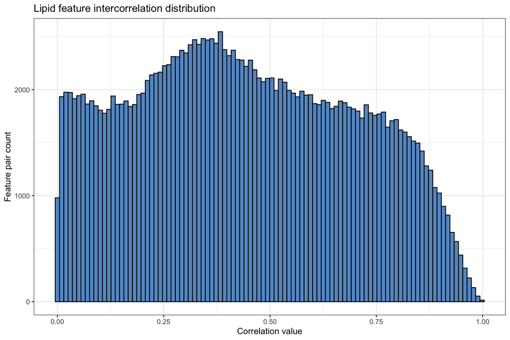

```r
# Calculate absolute correlation matrix of lipids, reformat then remove any rows with missing values. Then plot
(data$dfs$lipids %>% AbsCorMat() %>% gather() %>% filter(!is.na(value))) %>%
  ggplot(aes(x=value)) +
  geom_histogram(bins = 100,
                 colour = "black",
                 fill = Palette(2)[2]) +
  theme_bw() +
  xlab("Correlation value") +
  ylab("Feature pair count") +
  ggtitle("Lipid feature intercorrelation distribution")
```

We can look at how setting different intercorrelation thresholds impacts the number of features we retain:

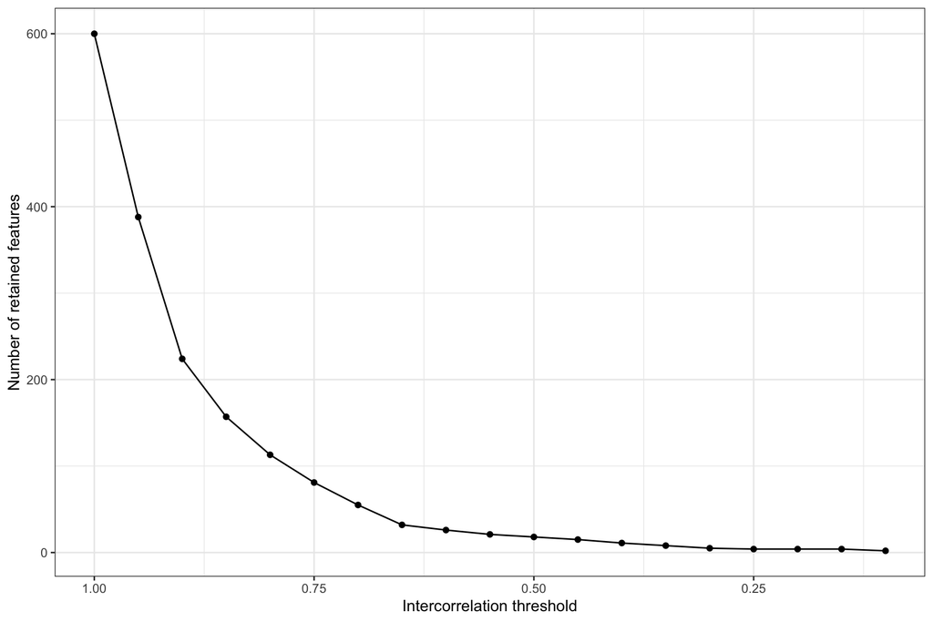

```r
Plot_Intercorrelation_Threshold(data$dfs$lipids)
```

We select a threshold of `0.8` using the *“elbow”* method.

```r
corThreshold <- 0.8
lipidsReduced <- Remove_Intercorrelated_Features(data$dfs$lipids,
                                                 corThreshold)
```

This leaves us with 113 lipids, compared to the starting quantity of 600. As discussed, there are many of these lipids which are unlikely going to not be very useful to analysis and so can be removed, especially if their information is captured by other lipid features. Now we can update our data object:

```r
# Update object
lipidIdx <- colnames(data$dfs$lipids) %in% colnames(lipidsReduced)
data$dfs$lipids <- lipidsReduced
data$features$lipids$ID <- data$features$lipids$ID[lipidIdx]
data$features$lipids$class <- data$features$lipids$class[lipidIdx]
```

### Proteins

The distribution of protein feature intercorrelations is a lot more encouraging, especially given their reduced quantity and greater likelihood for predictive power on the outcome variable.

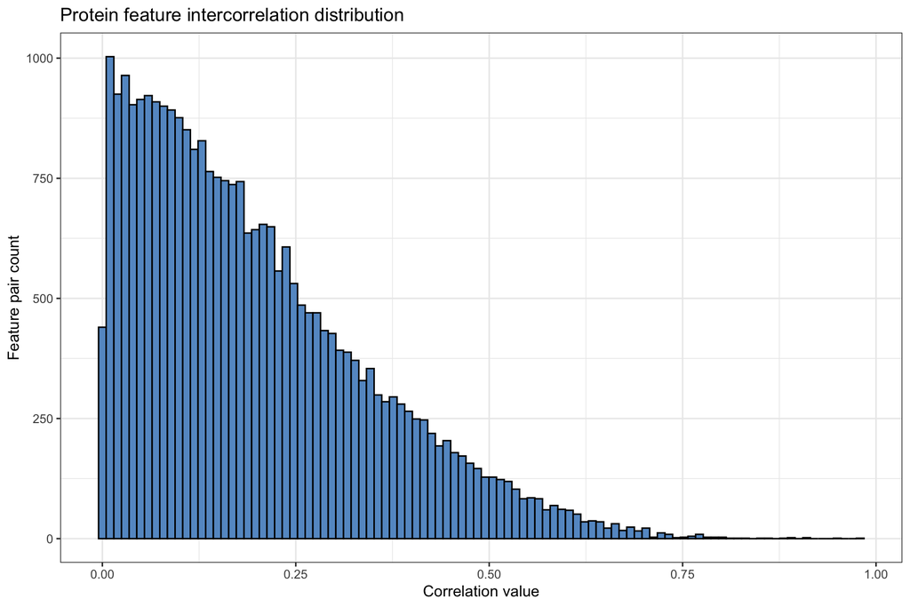

```r
# Calculate absolute correlation matrix of proteins, reformat then remove any rows with missing values. Then plot
(data$dfs$proteins %>% AbsCorMat() %>% gather() %>% filter(!is.na(value))) %>%
  ggplot(aes(x=value)) +
  geom_histogram(bins = 100,
                 colour = "black",
                 fill = Palette(2)[2]) +
  theme_bw() +
  xlab("Correlation value") +
  ylab("Feature pair count") +
  ggtitle("Protein feature intercorrelation distribution")
```

Once again, we will use the elbow method to select our retained number of features, setting it to a maximum of 0.7.

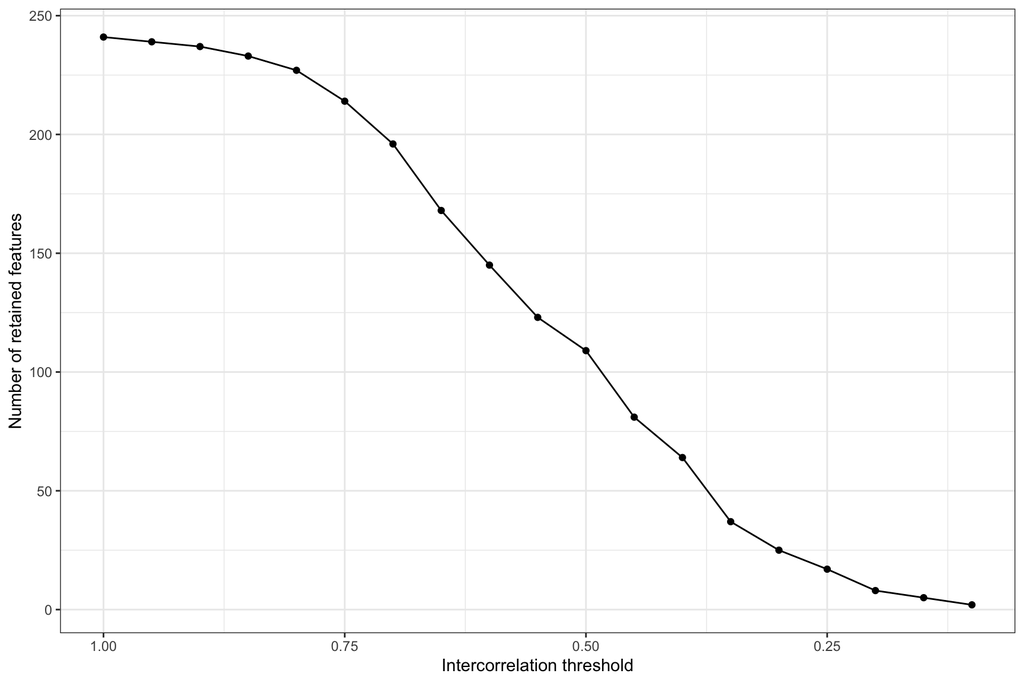

```r
Plot_Intercorrelation_Threshold(data$dfs$proteins)
```

```r
corThreshold <- 0.7
proteinsReduced <- Remove_Intercorrelated_Features(data$dfs$proteins,
                                                 corThreshold)
```

This leaves us with 196 proteins, compared to the starting quantity of 241. Now we can update our data object:

```r
# Update object
proteinIdx <- colnames(data$dfs$proteins) %in% colnames(proteinsReduced)
data$dfs$proteins <- proteinsReduced
data$features$proteins$ID <- data$features$proteins$ID[proteinIdx]
```

## Save Filtered data

```r
data %>% saveRDS(paste0(wd, "RDS/Data_Objects/filtered_data.rds"))
```

# Feature Engineering

Next, we will play around with feature engineering. I tried a few different methods, the two of which yielded the best results were multiplying lipid and protein features (referred here on out as *“factor features”*) and the ratio of lipid to protein features (referred here on out as *“ratio features”*).

The rough methodology works as follows:

*Important note: this methodology is not perfect as we are using our outcome variable to select features for a model on that outcome. However, due to the total sum of over 22000 possible pairs of lipid-proteins, we need a rigourous selection criteria. I explored various different methodologies (eg. top variable features), all of which were significantly effected by outliers.*

```r
# Scale features first
lipidScale <-  scale(data$dfs$lipids)
proteinScale <-  scale(data$dfs$proteins)

# Determine how many features we want from each method
nFeatPerMethod <- 100
```

## Factor of each variable pair

```r
factorFeats <- lapply(1:ncol(lipidScale), function(i) {
  # For each lipid ...
  lipid <- lipidScale[,i]

  o <- lapply(1:ncol(proteinScale), function(j) {
    # ... and protein pair
    protein <- proteinScale[,j]

    # Generate novel feature
    feat <- lipid * protein
    # Evaluate KW test. If significant, retain feature
    if (kruskal.test(feat, data$samples$group)$p.value < 0.05) {
      return(feat)
    }
    # Otherwise, return nothing
    return(rep(NA, 70))
  }) %>% as.data.frame()

  # Update column names of lipid specific dataframe
  colnames(o) <- paste0(colnames(lipidScale)[i],
                        "_", colnames(proteinScale),
                        "_factor")
  # Remove any features with all NAs (ie didnt pass KW test)
  o <- o[,colSums(is.na(o))==0,drop=F] %>% as.data.table()
  o
})

# Remove any lipid-specific dataframes with no features
factorFeats <- factorFeats[lapply(factorFeats, ncol) %>%
                                     unlist() > 0]
# Combine all features into one dataframe
factorFeats <- do.call(cbind, factorFeats)

# Calculate p-values for each feature via KW test
pVals <- factorFeats %>% lapply(function(f) {
  df <- cbind(val = f, group = data$samples$group)
  kruskal.test(val ~ group, df)$p.value
}) %>% unlist()

# Adjust for multiple-testing
pValAdj <- pVals %>% p.adjust("fdr")

# Determine which are top features based on adjusted p-value
topFeatNames <- sort(pValAdj, decreasing = T)[1:nFeatPerMethod] %>% names()
topFeatIdx <- which(colnames(factorFeats) %in% topFeatNames)

# Subset dataframe
factorFeats <- factorFeats[,topFeatIdx,with=F]
```

## Ratio of each variable pair

```r
ratioFeats <- lapply(1:ncol(lipidScale), function(i) {
  # For each lipid ...
  lipid <- lipidScale[,i]

  o <- lapply(1:ncol(proteinScale), function(j) {
    # ... and protein pair
    protein <- proteinScale[,j]

    # Generate novel feature
    feat <- lipid / protein
    # Evaluate KW test. If significant, retain feature
    if (kruskal.test(feat, data$samples$group)$p.value < 0.05) {
      return(feat)
    }
    # Otherwise, return nothing
    return(rep(NA, 70))
  }) %>% as.data.frame()

  # Update column names of lipid specific dataframe
  colnames(o) <- paste0(colnames(lipidScale)[i],
                        "_", colnames(proteinScale),
                        "_ratio")
  # Remove any features with all NAs (ie didnt pass KW test)
  o <- o[,colSums(is.na(o))==0,drop=F] %>% as.data.table()
  o
})

# Remove any lipid-specific dataframes with no features
ratioFeats <- ratioFeats[lapply(ratioFeats, ncol) %>%
                                     unlist() > 0]
# Combine all features into one dataframe
ratioFeats <- do.call(cbind, ratioFeats)

# Calculate p-values for each feature via KW test
pVals <- ratioFeats %>% lapply(function(f) {
  df <- cbind(val = f, group = data$samples$group)
  kruskal.test(val ~ group, df)$p.value
}) %>% unlist()

# Adjust for multiple-testing
pValAdj <- pVals %>% p.adjust("fdr")

# Determine which are top features based on adjusted p-value
topFeatNames <- sort(pValAdj, decreasing = T)[1:nFeatPerMethod] %>% names()
topFeatIdx <- which(colnames(ratioFeats) %in% topFeatNames)

# Subset dataframe
ratioFeats <- ratioFeats[,topFeatIdx,with=F]
```

## Combine two engineering methods

```r
# Combine both forms of feature engineering
data$dfs$engineered <- cbind(factorFeats, ratioFeats) %>% as.data.table()

# Determine which lipid, protein and method yielded novel feature
lipidName <- strsplit(colnames(data$dfs$engineered ), "_") %>%
  lapply(function(x) {x[1]}) %>% unlist()
proteinName <- strsplit(colnames(data$dfs$engineered ), "_") %>%
  lapply(function(x) {x[2]}) %>% unlist()
methodName <- strsplit(colnames(data$dfs$engineered ), "_") %>%
  lapply(function(x) {x[3]}) %>% unlist()

# Add to data object features
data$features$engineered <- data.table(lipid = lipidName,
                                    protein = proteinName,
                                    method = methodName)
```

## Check for redundant features

As per the suggestion of Patrick, we should check that there isn’t a factor and ratio feature using the same pair of lipid:protein pair. We can see below that there is one feature pair where both the factor and ratio combinations are included in this set of engineered features

```r
# Count frequency of lipid-protein pair occurances
uniqueEngineerPairs <- paste0(data$features$engineered$lipid,
                              "_",
                              data$features$engineered$protein) %>% table()
# Print any that occur more than once
which(uniqueEngineerPairs > 1)
```

```
## PE(P-16:0/22:4)_UN45A
##                   137
```

We’ll remove the ratio feature and retain the factor feature:

```r
# Determine where redundant feature is
redundantEngineerIdx <- which(data$features$engineered$lipid == "PE(P-16:0/22:4)" &
                                data$features$engineered$protein == "UN45A" &
                                data$features$engineered$method == "ratio")

# Remove from object
data$dfs$engineered <- data$dfs$engineered[,-redundantEngineerIdx,with=F]
data$features$engineered <- data$features$engineered[-redundantEngineerIdx,]
```

## Used features for engineering

### Lipids

Next, we can have a brief look at the lipid and protein features which were preferentially selected as part of feature engineering. The most commonly used lipid was `CE(12:0)`. There seems to be a variety of different lipid classes which were commonly used as part of feature engineering

```r
(data$features$engineered$lipid %>% table() %>% sort(decreasing = T))[1:10]
```

```
## .
##        CE(12:0)  DAG(18:1/20:5)   PE(18:1/18:1)  DAG(18:2/18:3)  TAG52:7-FA20:5
##               9               6               6               5               5
##       FFA(14:0)      HCER(16:0) PE(P-16:0/22:4)        SM(20:1)  TAG51:5-FA18:2
##               4               4               4               4               4
```

Below a histogram of the frequency of lipid usage can be seen. We can see that there were 38 lipids which were only used once in engineered features. Only a few lipids were used more than 3 times.

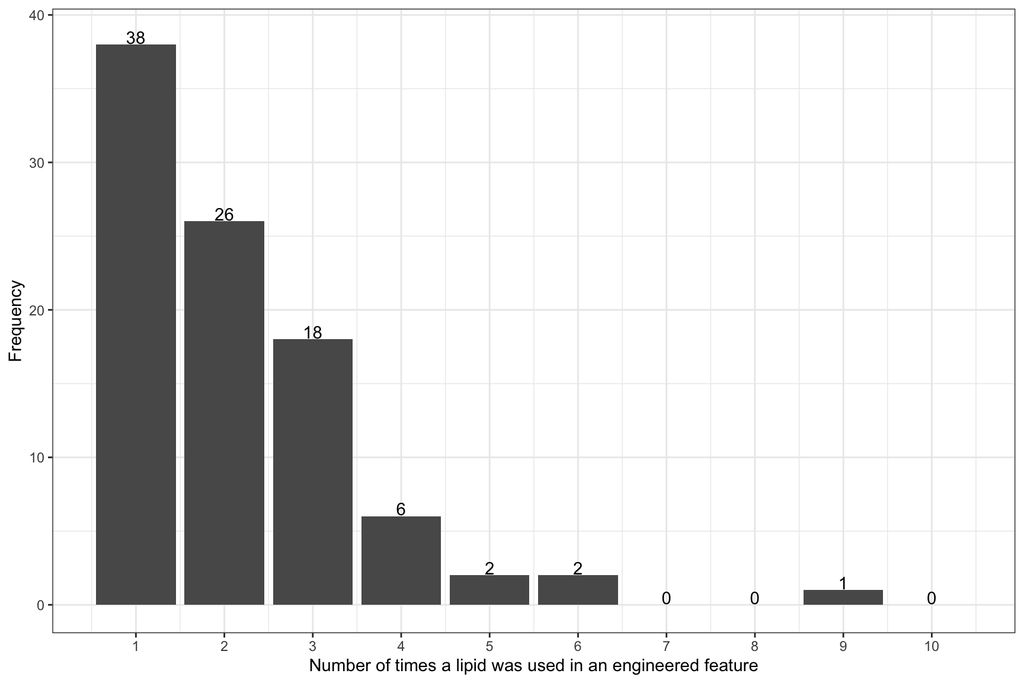

```r
# Calculate frequency of lipid use
table <- data$features$engineered$lipid %>%
  table() %>%
  Full.Table(all.vals = 1:10)

# Reformat into data.frame
plotDF <- cbind(as.integer(names(table)), as.integer(unname(table))) %>% as.data.table()
colnames(plotDF) <- c("Frequency", "Count")

# Plot
plotDF %>% ggplot(aes(x=Frequency, y = Count)) + geom_bar(stat = "identity") +
  theme_bw() +
  xlab("Number of times a lipid was used in an engineered feature") +
  ylab("Frequency") +
  scale_x_continuous(breaks = 1:10) +
  geom_text(aes(label = Count),
            nudge_y = 0.5)
```

### Proteins

We can see here the most used protein features as part of engineering.

```r
(data$features$engineered$protein %>% table() %>% sort(decreasing = T))[1:10]
```

```
## .
##  APOD  AFAM  NGAL PSIP1   C1S  CERU   CO6   KIT  AATM ANXA6
##     7     6     5     5     4     4     4     4     3     3
```

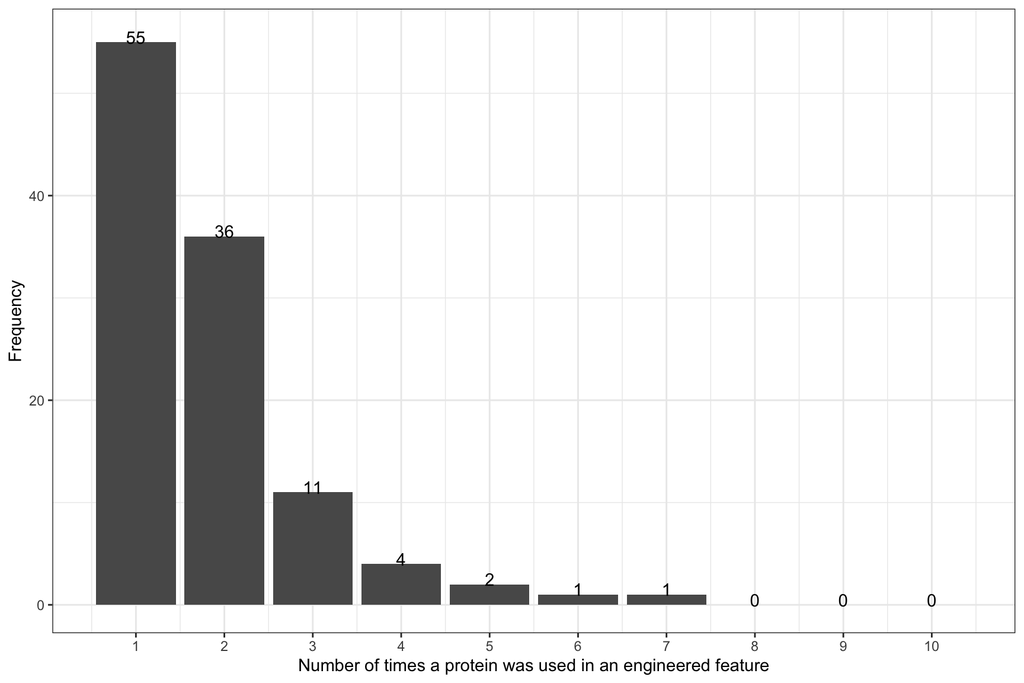

```r
# Calculate frequency of protein use
table <- data$features$engineered$protein %>%
  table() %>%
  Full.Table(all.vals = 1:10)

# Reformat into data.frame
plotDF <- cbind(as.integer(names(table)), as.integer(unname(table))) %>% as.data.table()
colnames(plotDF) <- c("Frequency", "Count")

# Plot
plotDF %>% ggplot(aes(x=Frequency, y = Count)) + geom_bar(stat = "identity") +
  theme_bw() +
  xlab("Number of times a protein was used in an engineered feature") +
  ylab("Frequency") +
  scale_x_continuous(breaks = 1:10) +
  geom_text(aes(label = Count),
            nudge_y = 0.5)
```

## Basic model using engineered features

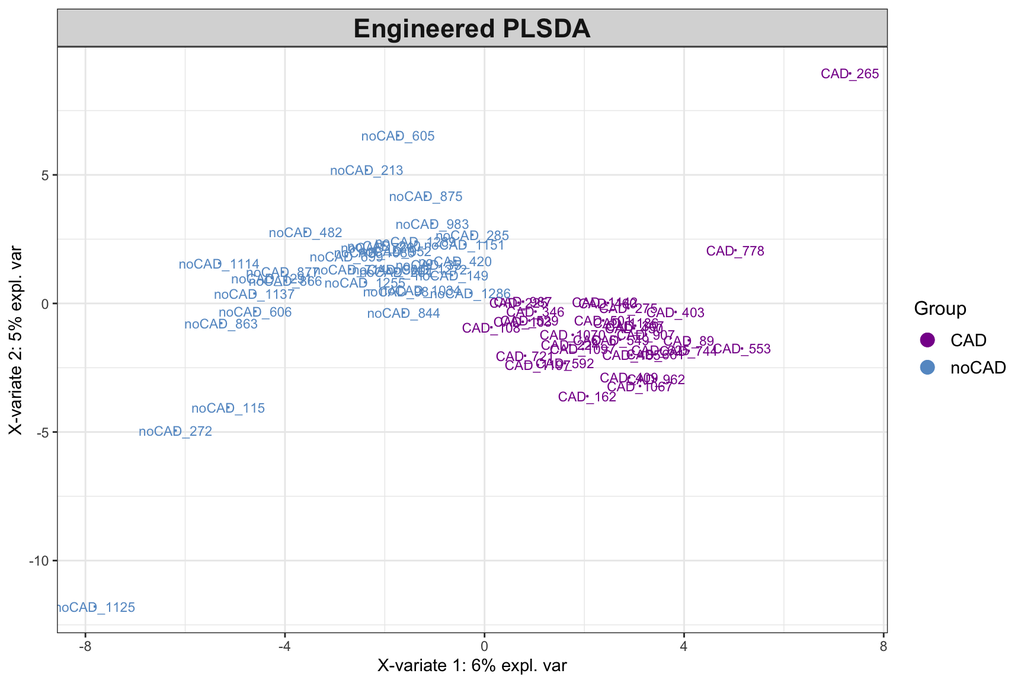

```r
plsdaObj <- plsda(data$dfs$engineered,
                  data$samples$group)

plotIndiv(plsdaObj,
          ind.names= data$samples$names,
          group = data$samples$group,
          legend = TRUE,
          legend.title = 'Group',
          title = "Engineered PLSDA",
          col = Group.Palette)
```

## Save Engineered data

```r
data %>% saveRDS(paste0(wd, "RDS/Data_Objects/engineered_data.rds"))
```